# Normality Check and Pre/Post significance test

Zoe Zhou

21/01/2020

### Read in data

```r
library(readxl)
supine <- read_excel("PeakPFMCCompare.xlsx", sheet = "Supine")
upright <- read_excel("PeakPFMCCompare.xlsx", sheet = "Upright")
```

### Have a look of the distribution of Supine data (PreSup)

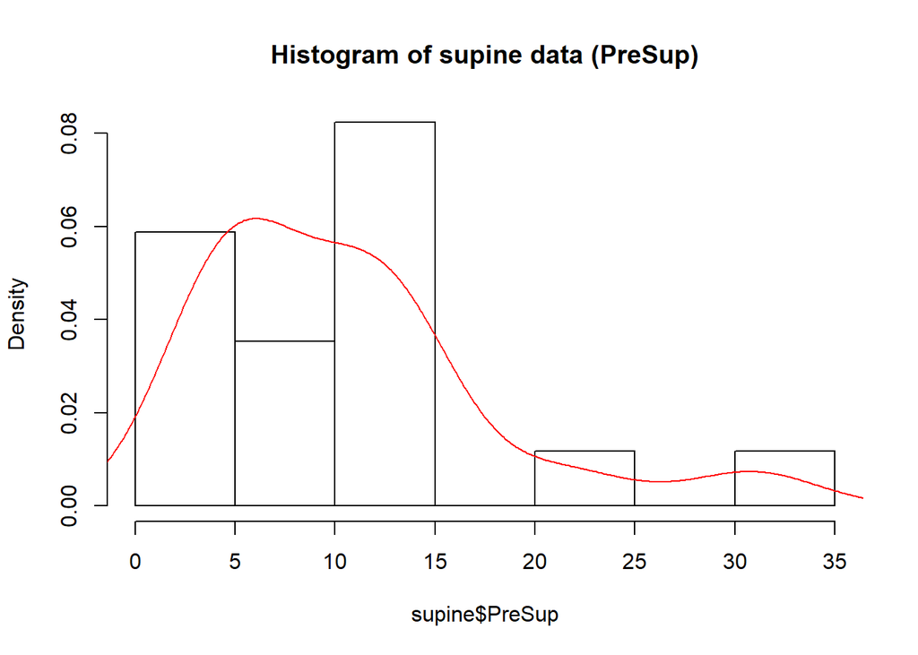

```r
# Supine dataset
# Density plot for presup
hist(supine$PreSup, probability = TRUE,
     main = "Histogram of supine data (PreSup)")
lines(density(supine$PreSup),col = 2)
```

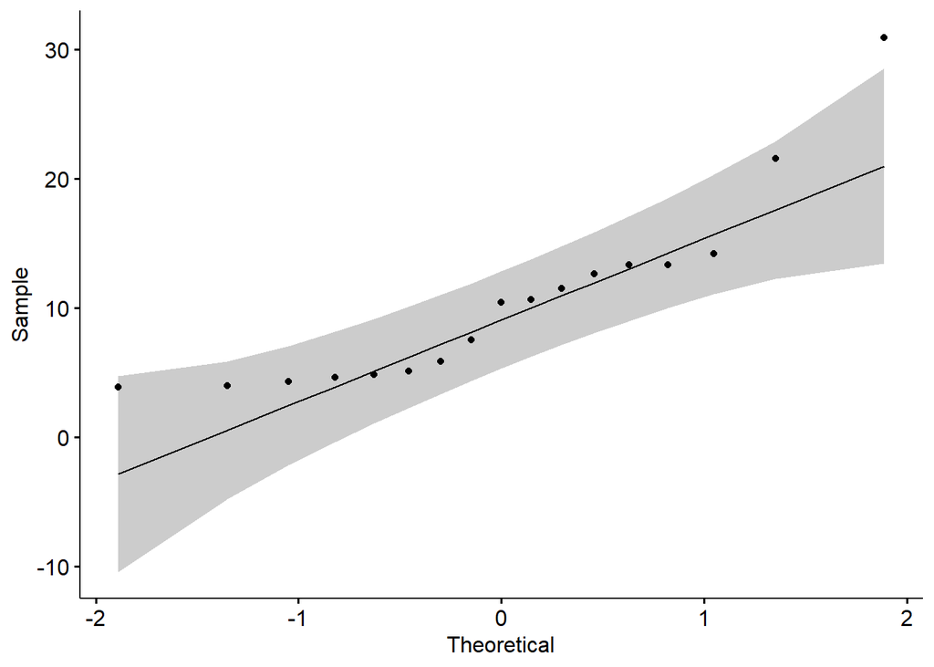

```r
# QQ plot
library(ggpubr)
ggqqplot(supine$PreSup)
```

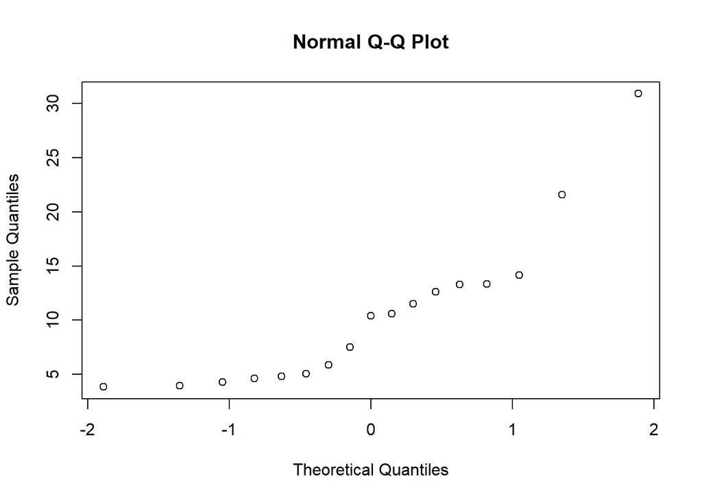

```r
qqnorm(supine$PreSup)
```

### Shapiro-Wilk’s test

```r
shapiro.test(supine$PreSup)
```

```
##
##  Shapiro-Wilk normality test
##
## data:  supine$PreSup
## W = 0.82432, p-value = 0.00446
```

### Comment

P-value of 0.004 suggests we have strong evidence against normality. We might have skewed data. Sample size of 17 (< 30), the test statistics might not be useful.

### Have a look of the distribution of Supine data (PostSup)

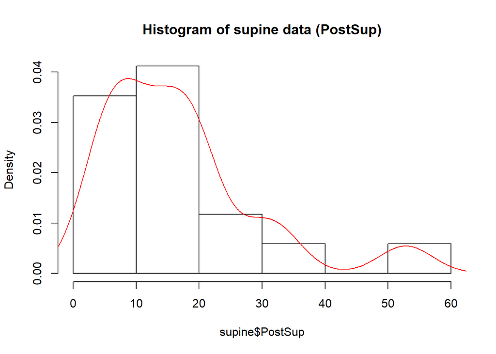

```r
# Density plot for postsup
hist(supine$PostSup, probability = TRUE, main = "Histogram of supine data (PostSup)")
lines(density(supine$PostSup), col = 2)
```

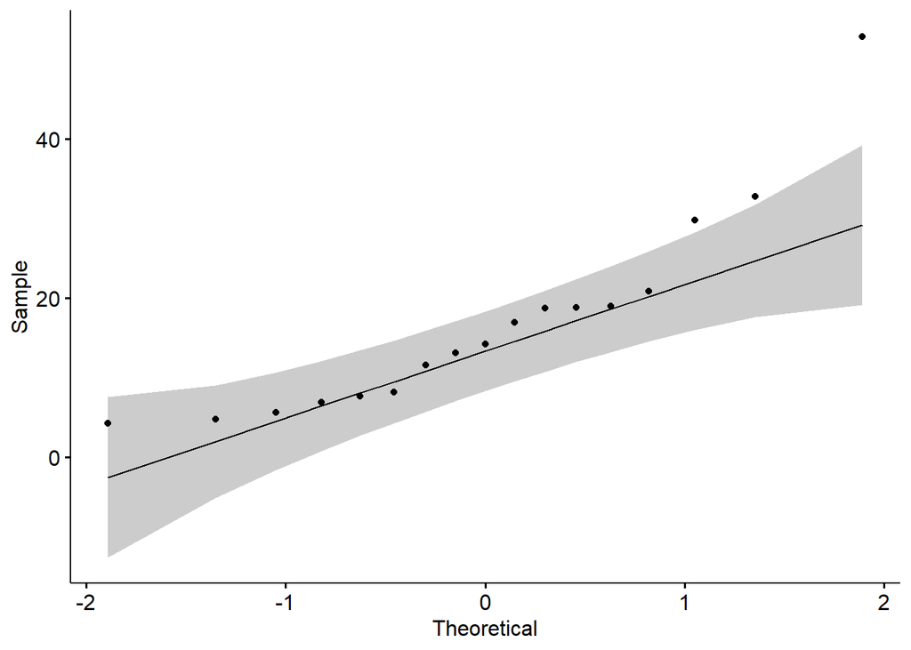

```r
# QQ plot
ggqqplot(supine$PostSup)
```

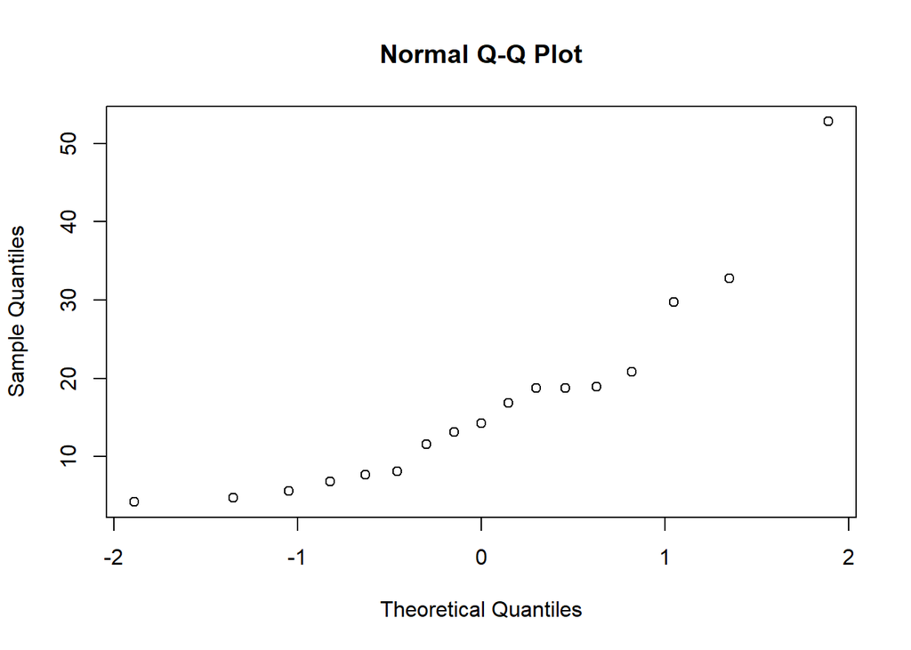

```r
qqnorm(supine$PostSup)
```

### Shapiro-Wilk’s test

```r
shapiro.test(supine$PostSup)
```

```
##
##  Shapiro-Wilk normality test
##
## data:  supine$PostSup
## W = 0.84437, p-value = 0.008811
```

### Comment

P-value of 0.008 suggests we have strong evidence against normality. We might have skewed data. Sample size of 17 (< 30), the test statistics might not be useful.

```r
library(tidyverse)
```

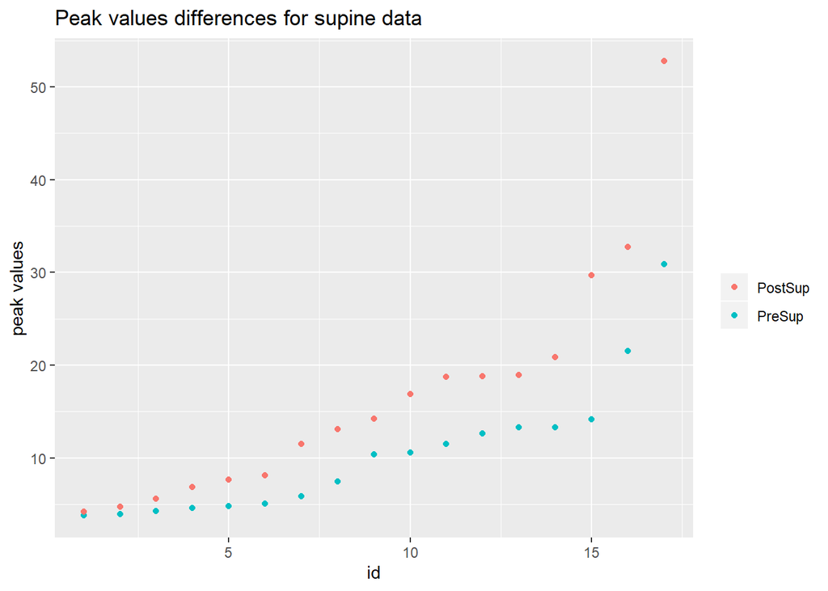

```r
tidysupine = supine %>%
  mutate(id = 1:nrow(supine)) %>%
  gather(group, peakvalue, c(PreSup, PostSup))


qplot(x = tidysupine$id, y = tidysupine$peakvalue, color = tidysupine$group,
      xlab = "id", ylab = "peak values", main = "Peak values differences for supine data") +
  scale_color_discrete(name = "")
```

### Have a look of the distribution of Upright data (PreUp)

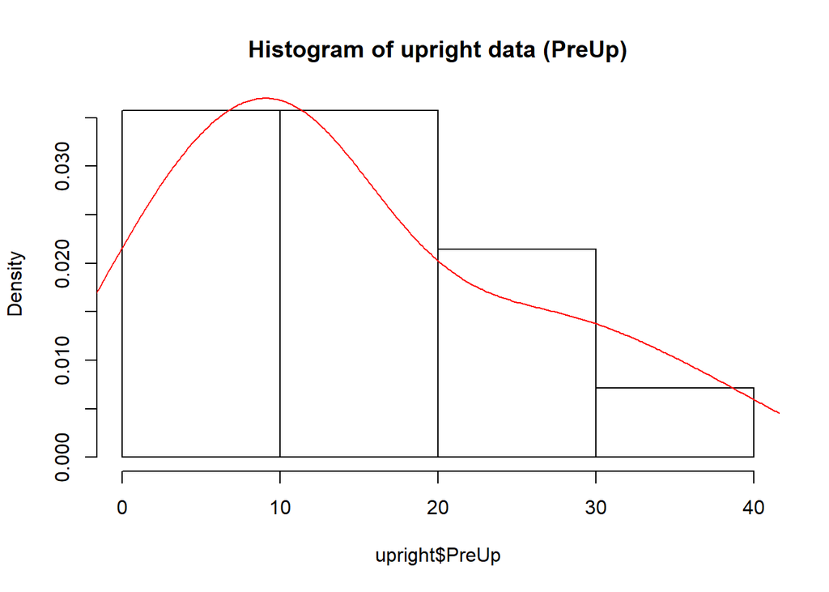

```r
# Upright dataset
# Density plots for preup
hist(upright$PreUp, probability = TRUE, main = "Histogram of upright data (PreUp)")
lines(density(upright$PreUp), col = 2)
```

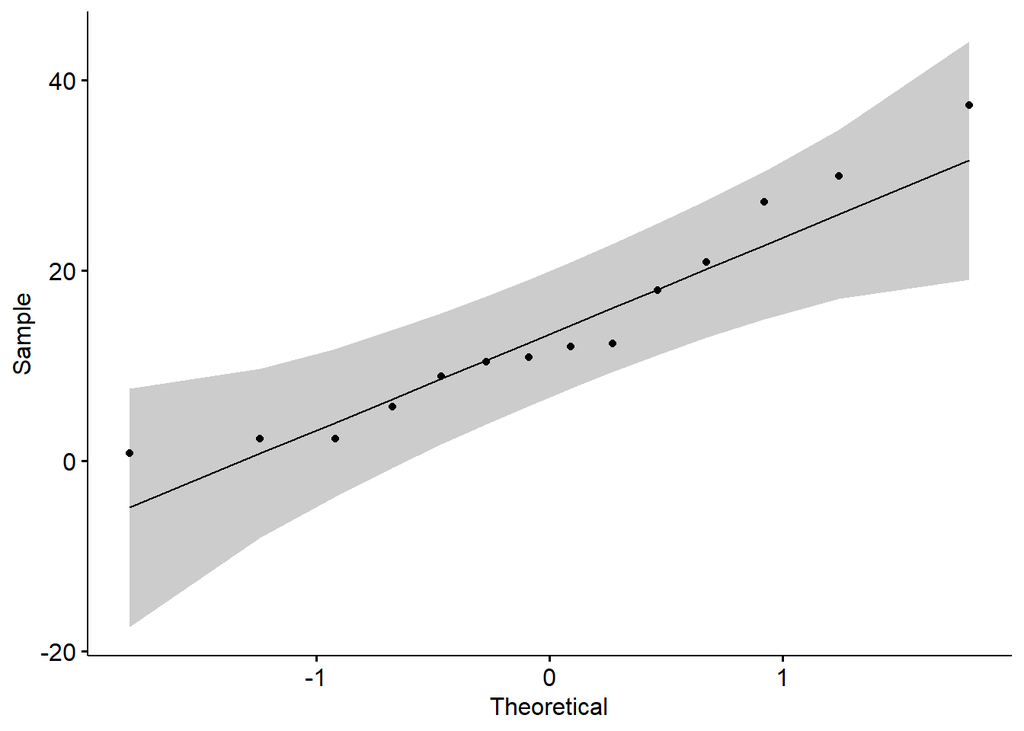

```r
# QQ plot
ggqqplot(upright$PreUp)
```

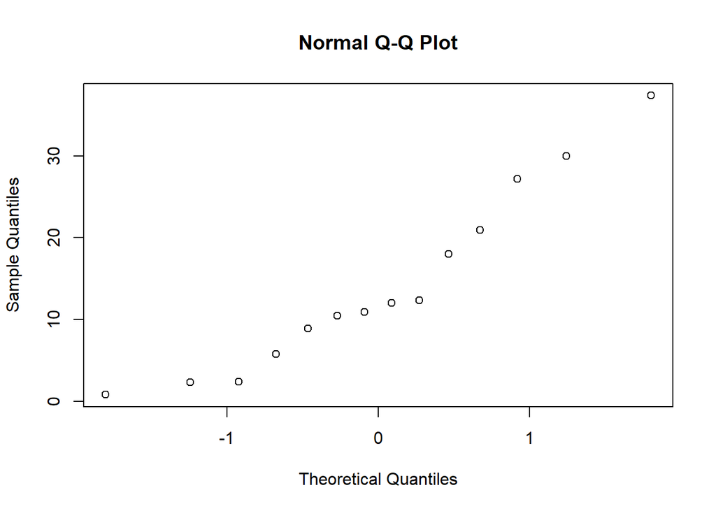

```r
qqnorm(upright$PreUp)
```

### Shapiro-Wilk’s test

```r
shapiro.test(upright$PreUp)
```

```
##
##  Shapiro-Wilk normality test
##
## data:  upright$PreUp
## W = 0.92233, p-value = 0.2375
```

### Comment

P-value of 0.2375 suggests no much evidence against normality. We might have normal distributed data. Sample size of 14 (< 30), the test statistics might not be useful.

### Have a look of the distribution of Upright data (PostUp)

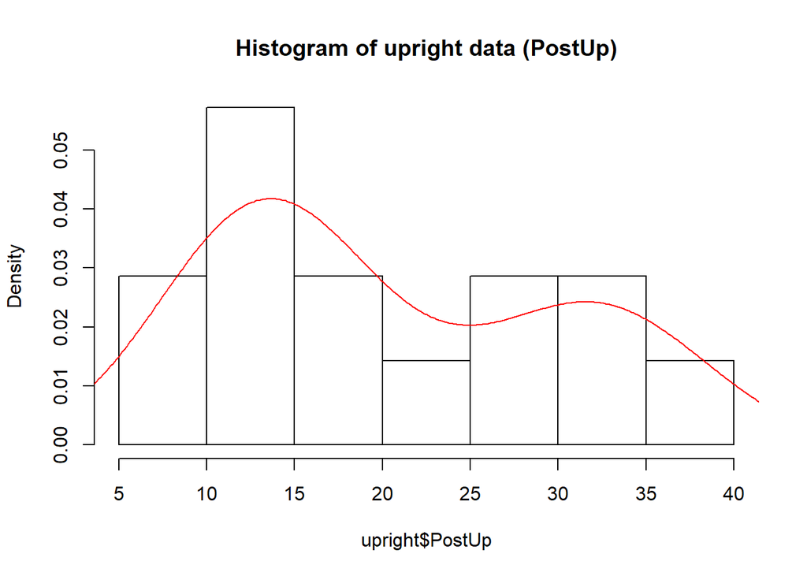

```r
# Density plot for postup
hist(upright$PostUp, probability = TRUE, main = "Histogram of upright data (PostUp)")
lines(density(upright$PostUp), col = 2)
```

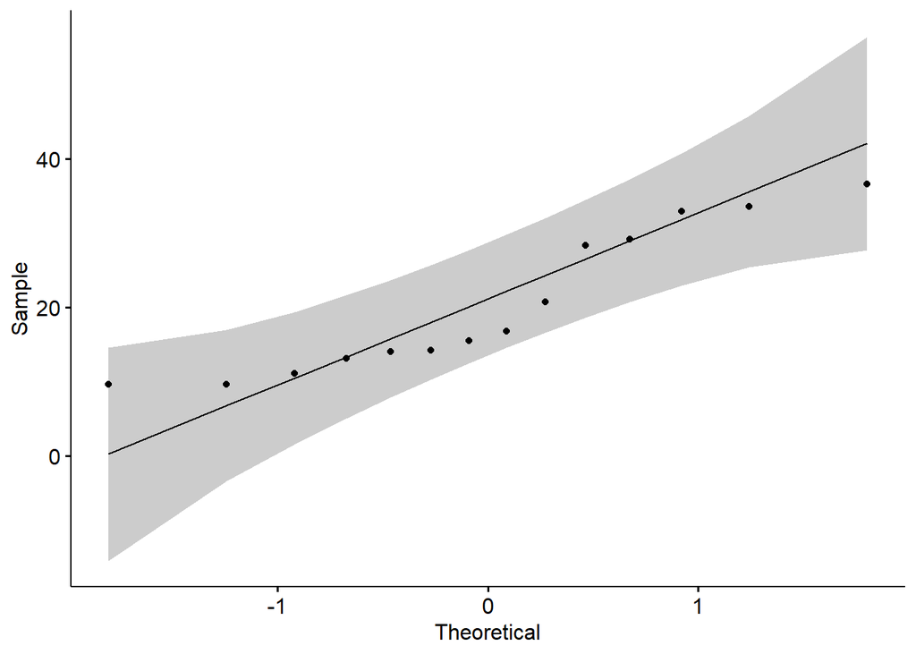

```r
# QQ plot
ggqqplot(upright$PostUp)
```

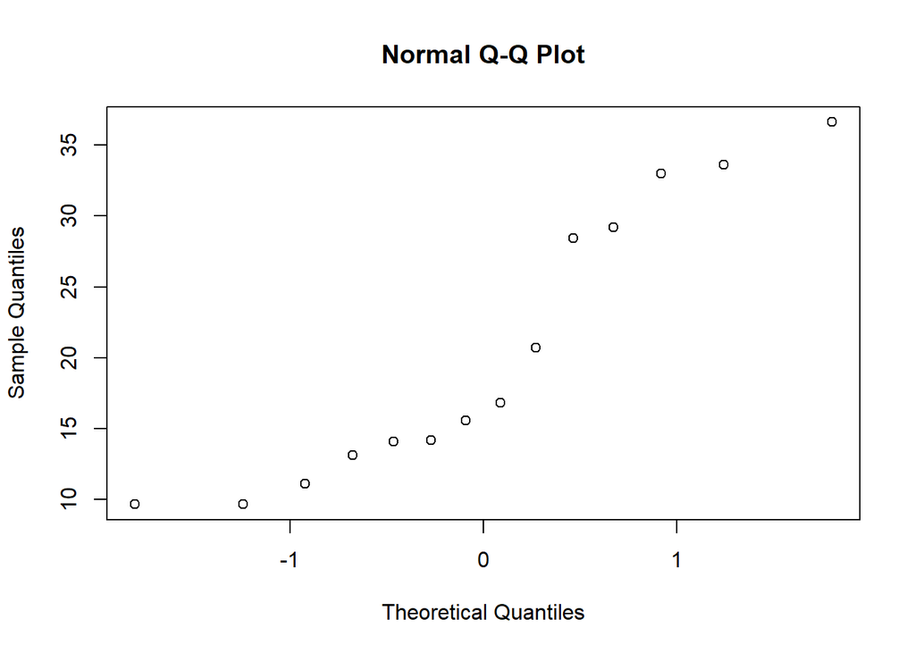

```r
qqnorm(upright$PostUp)
```

### Shapiro-Wilk’s test

```r
# Shapiro-Wilk’s test
shapiro.test(upright$PostUp)
```

```
##
##  Shapiro-Wilk normality test
##
## data:  upright$PostUp
## W = 0.87241, p-value = 0.04537
```

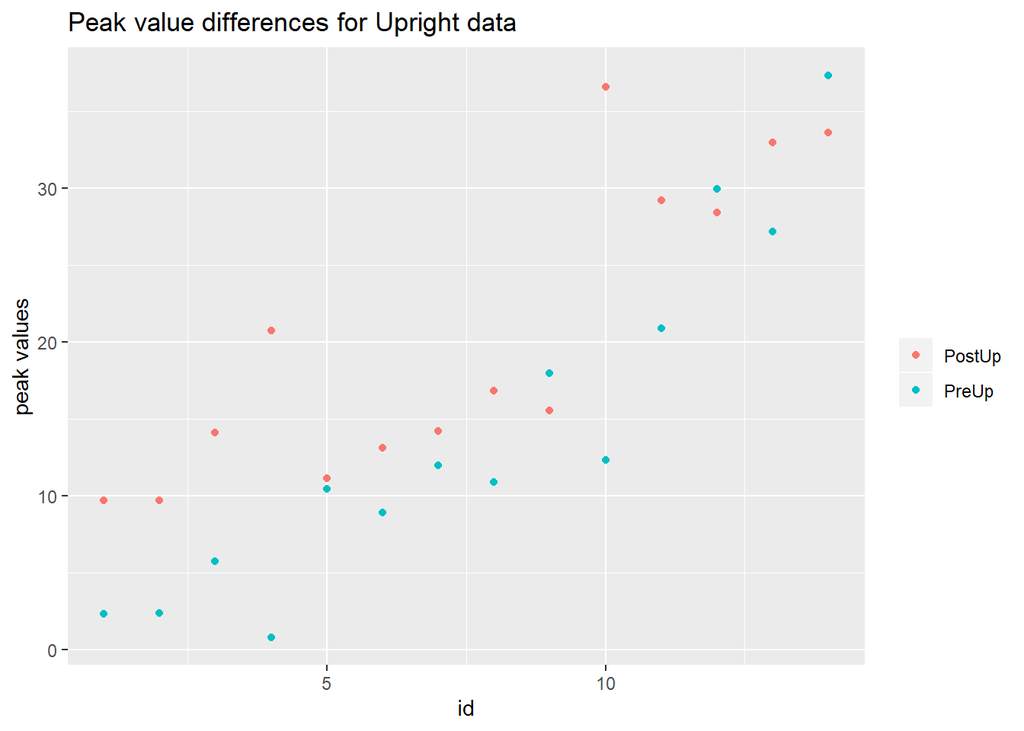

```r
tidyupright = upright %>%
  mutate(id = 1:nrow(upright)) %>%
  gather(group, peakvalue, c(PreUp, PostUp))

# Order the data first
meantbl = tidyupright %>%
  group_by(id) %>%
  summarise(meanpeak = mean(peakvalue))

tidyupright$rank = rep(order(order(meantbl$meanpeak)), 2)

qplot(x = tidyupright$rank, y = tidyupright$peakvalue,
      color = tidyupright$group, xlab = "id", ylab = "peak values",
      main = "Peak value differences for Upright data") +
  scale_color_discrete(name = "")
```

### Wilcoxon signed-rank Test on Supine data

```r
wilcox.test(peakvalue ~ group, data = tidysupine, paired = TRUE)
```

```
##
##  Wilcoxon signed rank test
##
## data:  peakvalue by group
## V = 153, p-value = 1.526e-05
## alternative hypothesis: true location shift is not equal to 0
```

### Comment

The p-value of the test is 1.526e-05(<0.05). We can conclude that the median peak values of the patients before treatment is significantly different from the median peak values after treatment.

#### Plot the data side by side

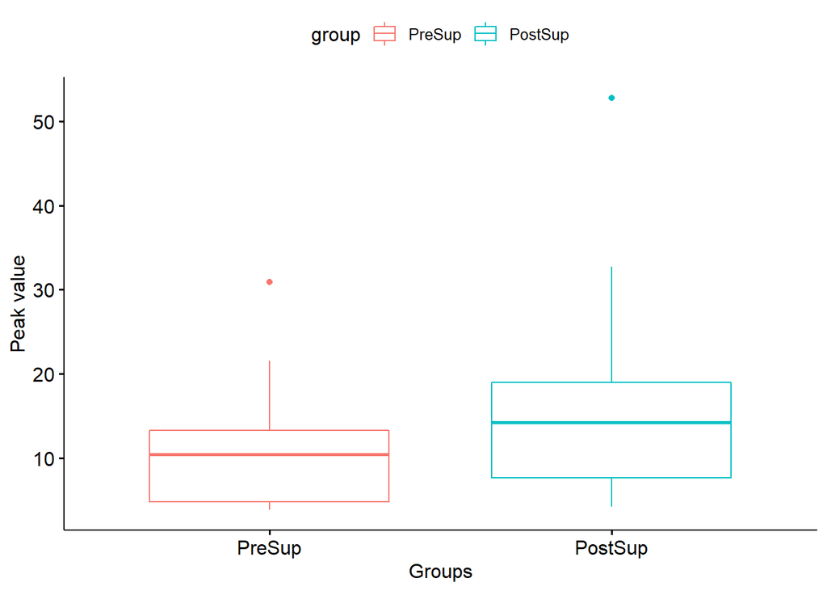

```r
library("ggpubr")
ggboxplot(tidysupine, x = "group", y = "peakvalue",
          color = "group", ylab = "Peak value", xlab = "Groups")
```

### Are the Pre/Post differences significant?

### Wilcoxon signed-rank Test on Upright data

```r
wilcox.test(peakvalue ~ group, data = tidyupright, paired = TRUE)
```

```
##
##  Wilcoxon signed rank test
##
## data:  peakvalue by group
## V = 94, p-value = 0.006714
## alternative hypothesis: true location shift is not equal to 0
```

#### Plot the data side by side

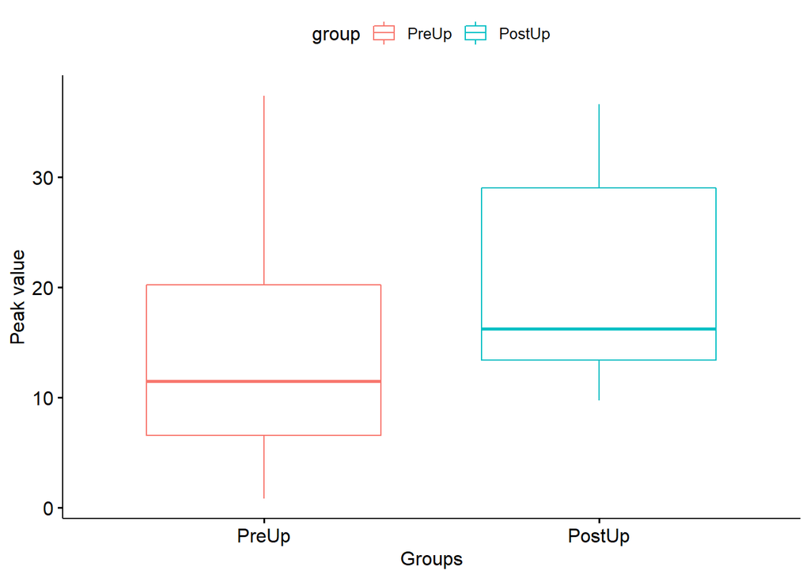

```r
ggboxplot(tidyupright, x = "group", y = "peakvalue",
          color = "group", ylab = "Peak value", xlab = "Groups")
```